# Machine Learning writeup

Eduardo B. Diez

Tuesday, August 12, 2014

# Introduction

The goal of your project is to predict the manner in which they did the exercise. This is the “classe” variable in the training set.

You may use any of the other variables to predict with. You should create a report describing

1. how you built your model,
2. how you used cross validation,
3. what you think the expected out of sample error is,
4. and why you made the choices you did.

You will also use your prediction model to predict 20 different test cases.

1 Has the student submitted a github repo?

# Cleaning the Data

After inspection and work with the data we arrive to the conclusion that the variable we can considerer as real feature are:

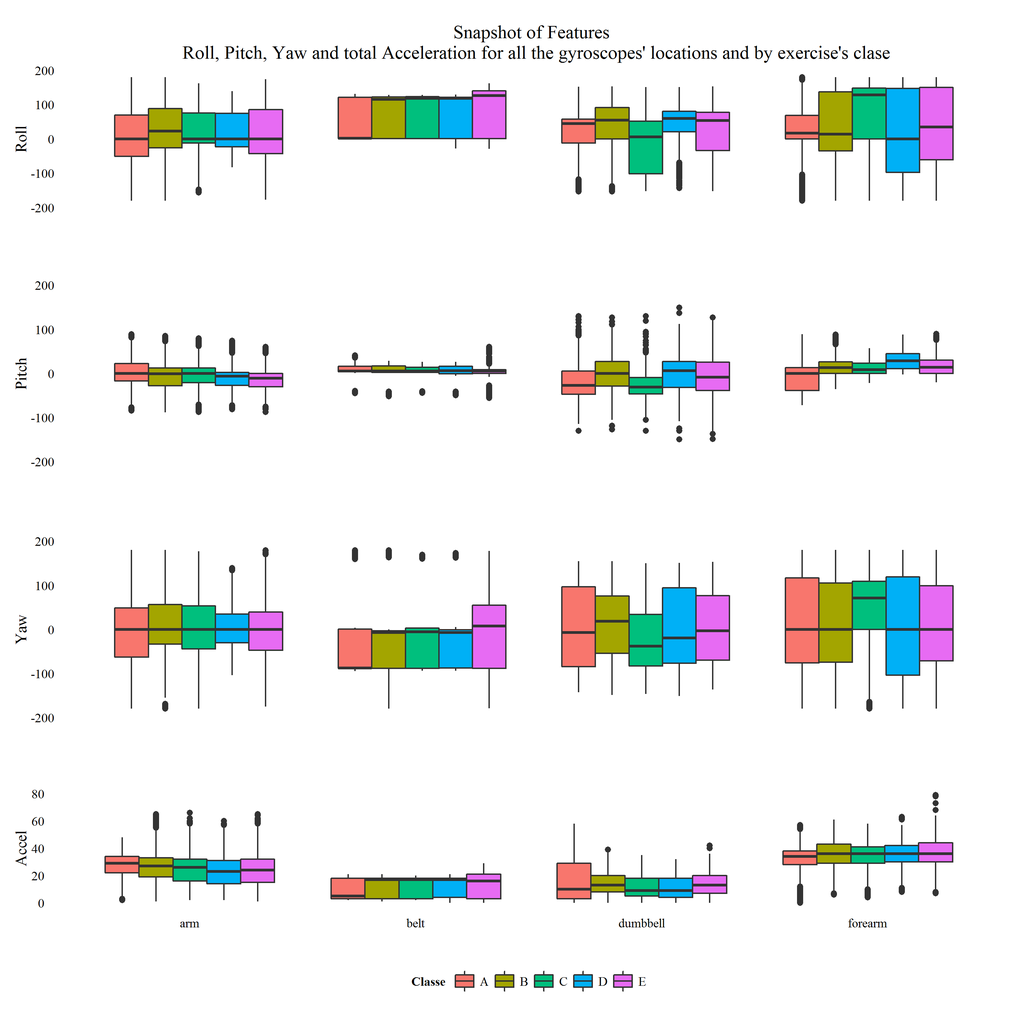

Figure 1. Initial set of features selected; Roll, Pitch, Yaw and total acceleration.

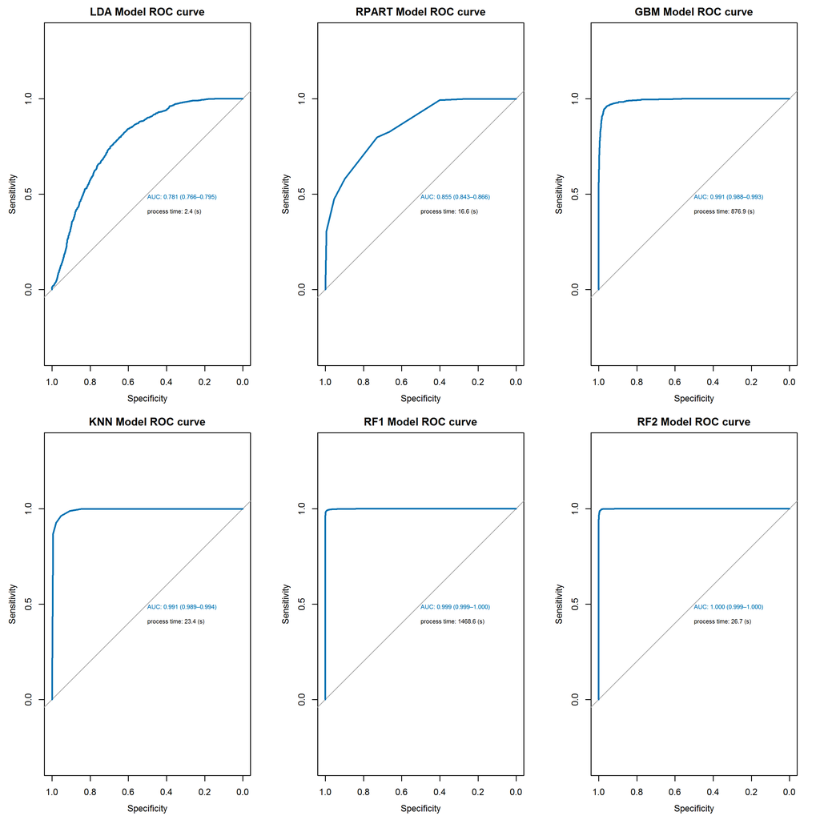

Figure 2. The ROC curves for the models with the total AUC (Area Under the Curve) with 95% confidence interval and the total process time running in Mobile Intel Core 2 T6400 at 2GHz with 4GB